# Meta analyses robustness tests

Comparing logistic vs linear probability mixed effects models

Ian Hussey

09 April, 2020

McCabe, Halvorson, King, Cao, & Kim (2020) recently demonstrated that estimates of interaction effects in logistic regression can be unstable, on the basis that independence between IVs is violated when using a non linear/metric link function. WHile McCabe et al. provided suggestions and code to implement novel methods to test for such interactions, thus far these can only be applied in the context of fixed effects models. Given we employ mixed effects models here, an alternative strategy of testing robustness was divised. Specifically, we employed a linear probability model to overcome the violation of non-independence that McCabe highlighted in logistic models.

As such, we included the following robustness test. The multilevel logistic models reported in the main analyses and meta analyses were replaced with multilevel linear probability models. Interaction effects were then meta analyzed across experiments, as in the main analyses. Unlike the robustness tests for the fixed effects models, only the congruence in conclusions could be compared (i.e., p values between logistic and linear probability models), as Odds Ratios and linear probabilities cannot be directly compared. p values for the logistic models are reported in the main meta analyses.

Code/analyses are adapted from the meta analyses. Meta analyses of the key hypothesis tests are refitted, i.e., influence rates predicting IA-AMP effects.

```r
# dependencies
library(tidyverse)
library(timesavers)
library(lme4)
library(effects)
library(metafor)
library(patchwork)
library(ggExtra)
library(sjPlot)
library(kableExtra)
library(knitr)

# disable scientific notation
options(scipen = 999)

# knitr output for html
options(knitr.table.format = "html")


# custom functions --------------------

zscore_to_p <- function(z){
  2*pnorm(-abs(z))
}

# fit models to individual experiments and extract an effect of interest
fit_lmer_model_and_extract_effect <- function(data, experiment_n, formula, effect, domain_name = NULL) {
  require(tidyverse)

  if (!is.null(domain_name)) {

    fit <- data %>%
      dplyr::filter(experiment == experiment_n &
                      domain == domain_name) %>%
      lmer(formula = formula,
           data = .)

    results <-
      summary(fit)$coefficients %>%
      as.data.frame() %>%
      rownames_to_column(var = "Effect") %>%
      dplyr::filter(Effect == effect) %>%
      mutate(Experiment = experiment_n,
             domain = domain_name,
             yi = Estimate,       # effect size
             vi = `Std. Error`^2) # convert SE to variance

  } else {

    fit <- data %>%
      dplyr::filter(experiment == experiment_n) %>%
      lmer(formula = formula,
           data = .)

    results <-
      summary(fit)$coefficients %>%
      as.data.frame() %>%
      rownames_to_column(var = "Effect") %>%
      dplyr::filter(Effect == effect) %>%
      mutate(Experiment = experiment_n,
             yi = Estimate,       # effect size
             vi = `Std. Error`^2) # convert SE to variance

  }

  return(results)
}


# get data
combined_trial_level_data       <- read.csv("../data/combined_trial_level_data.csv") %>%
  mutate(influenced = as.logical(influenced))
```

# Does influence rate predict the magnitude of (IA)AMP effects?

## IA-AMP

### Trial level

#### Interaction effect

Positive-negative IA-AMPs only (i.e., no Politics IA-AMP), as trial level data reveals the magnitude of the AMP effect but not the absolute magnitude. When there are meaningful individual differences between the positive and negative category (i.e., the Politics IA-AMP but not the positive-negative IA-AMP), the native trial level AMP effects between groups conceal the absolute magnitudes. As such, it is only meaningful to meta analyze the positive-negative IA-AMP effects.

```r
formula <- as.formula("rating ~ prime_type * influenced + (1 | unique_id)")
effect  <- "prime_typePositive:influencedTRUE"

# apply models to individual experiments, extract results for key effect
results_for_meta_analysis_2_linearprobabiility <- rbind(
  fit_lmer_model_and_extract_effect(data = combined_trial_level_data,
                                    experiment_n = 1,
                                    domain_name = "Generic valence",
                                    formula = formula,
                                    effect = effect),
  fit_lmer_model_and_extract_effect(data = combined_trial_level_data,
                                    experiment_n = 2,
                                    domain_name = "Generic valence",
                                    formula = formula,
                                    effect = effect),
  fit_lmer_model_and_extract_effect(data = combined_trial_level_data,
                                    experiment_n = 3,
                                    domain_name = "Generic valence",
                                    formula = formula,
                                    effect = effect),
  fit_lmer_model_and_extract_effect(data = combined_trial_level_data,
                                    experiment_n = 4,
                                    domain_name = "Generic valence",
                                    formula = formula,
                                    effect = effect),
  fit_lmer_model_and_extract_effect(data = combined_trial_level_data,
                                    experiment_n = 5,
                                    domain_name = "Generic valence",
                                    formula = formula,
                                    effect = effect)
)
```

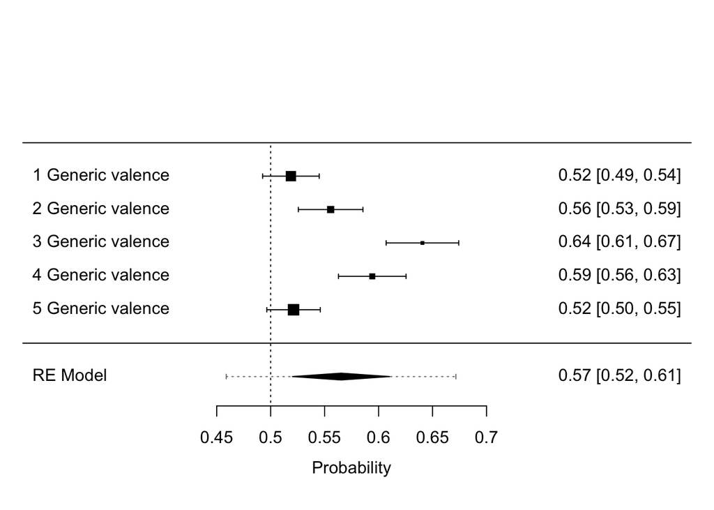

```r
# reshape data
data_temp_linearprobabiility <- results_for_meta_analysis_2_linearprobabiility %>%
  dplyr::rename(V = vi)

# fit
fit_linearprobabiility <-
  rma.mv(yi     = yi,
         V      = V,
         random = ~ 1 | Experiment/domain,
         data   = data_temp_linearprobabiility,
         slab   = paste(Experiment, domain))

# plot
forest(fit_linearprobabiility,
       xlab = "Probability",
       addcred = TRUE,
       refline = 0.5)
```

```r
summary(fit_linearprobabiility)
```

```
##
## Multivariate Meta-Analysis Model (k = 5; method: REML)
##
##   logLik  Deviance       AIC       BIC      AICc
##   6.1835  -12.3669   -6.3669   -8.2080   17.6331
##
## Variance Components:
##
##             estim    sqrt  nlvls  fixed             factor
## sigma^2.1  0.0012  0.0348      5     no         Experiment
## sigma^2.2  0.0012  0.0348      5     no  Experiment/domain
##
## Test for Heterogeneity:
## Q(df = 4) = 45.3598, p-val < .0001
##
## Model Results:
##
## estimate      se     zval    pval   ci.lb   ci.ub
##   0.5652  0.0230  24.5894  <.0001  0.5202  0.6103  ***
##
## ---
## Signif. codes:  0 '***' 0.001 '**' 0.01 '*' 0.05 '.' 0.1 ' ' 1
```